# Projeto de Estatística Aplicada a Telemática

Aluno: Antonio Dartagnan Santos da Costa Junior Professor: Paulo Ribeiro Lins Junior

# Análise dos dados do Bolsa Família nos últimos dez anos

### Dados disponíveis em http://dados.gov.br/dataset/bolsa-familia-misocial

O objetivo desse projeto é fazer uma análise da relação de famílias com os valores repassados pelo bolsa família no estado da paraíba, e em âmbito nacional montar um rank de regiões, estados e capitais que receberam o maior montante do valor repassado do bolsa família no Brasil. Todos os aquivos .csv do bolsa família possuem 4 colunas, que são: 1- ibge, referente a cidade que o dado foi coletado; 2- anomes, referente ao ano e o mês do ano que o dado foi coletado; 3- qtd_familias_benificiarias, referente a quantas famílias receberam o auxílio naquele mês; 4- valor_repassado, referente ao valor total repassado para cidade no mês.

## Iniciando a codificação do projeto

```python
import pandas as pd
import numpy as np
import matplotlib.pyplot as plt
%matplotlib inline
```

### Carregando dados da Paraíba

```python
data_frame_pb = pd.read_csv("http://aplicacoes.mds.gov.br/sagi/servicos/misocial?q=*&fq=sigla_uf:PB&fq=tipo_s:mes_mu&wt=csv&fl=ibge:codigo_ibge,anomes:anomes_s,qtd_familias_beneficiarias_bolsa_familia,valor_repassado_bolsa_familia&rows=10000000&sort=anomes_s%20asc,%20codigo_ibge%20asc")
```

O estado da Paraíba possui 223 cidades. Primeiramente fiz uma mudança no csv original, mudei o ID do IBGE de cada cidade por seu nome, pois assim seria melhor de fazer a análise dos dados de cada cidade.

```python
data_frame_pb['ibge'].replace(({250010:'Água Branca', 250020:'Aguiar', 250030:'Alagoa Grande', 250040:'Alagoa Nova', 250050:'Alagoinha',
                               250053:'Alcantil', 250057:'Algodão de Jandaíra', 250060:'Alhandra',  250070:'São João do Rio do Peixe',
                               250073:'Amparo', 250077:'Aparecida', 250080:'Araçagi', 250090:'Arara', 250100:'Araruna', 250110:'Areia', 250115:'Areia de Baraúnas', 250120:'Areial',
250130:'Aroeiras', 250135:'Assunção', 250140:'Baía da Traição', 250150:'Bananeiras', 250153:'Baraúna',
250157:'Barra de Santana', 250160:'Barra de Santa Rosa', 250170:'Barra de São Miguel', 250180:'Bayeux', 250190:'Belém',
250200:'Belém do Brejo do Cruz', 250205:'Bernardino Batista', 250210:'Boa Ventura', 250215:'Boa Vista', 250220:'Bom Jesus',
250230:'Bom Sucesso', 250240:'Bonito de Santa Fé', 250250:'Boqueirão', 250260:'Igaracy', 250270:'Borborema', 250280:'Brejo do Cruz',
250290:'Brejo dos Santos', 250300:'Caaporã', 250310:'Cabaceiras', 250320:'Cabedelo', 250330:'Cachoeira dos Índios',
250340:'Cacimba de Areia', 250350:'Cacimba de Dentro', 250355:'Cacimbas', 250360:'Caiçara', 250370:'Cajazeiras',
250375:'Cajazeirinhas', 250380:'Caldas Brandão', 250390:'Camalaú', 250400:'Campina Grande', 250403:'Capim',
250407:'Caraúbas', 250410:'Carrapateira', 250415:'Casserengue', 250420:'Catingueira', 250430:'Catolé do Rocha',
250435:'Caturité', 250440:'Conceição', 250450:'Condado', 250460:'Conde', 250470:'Congo', 250480:'Coremas',
250485:'Coxixola', 250490:'Cruz do Espírito Santo', 250500:'Cubati', 250510:'Cuité', 250520:'Cuitegi',
250523:'Cuité de Mamanguape', 250527:'Curral de Cima', 250530:'Curral Velho', 250535:'Damião',
250540:'Desterro', 250550:'Vista Serrana', 250560:'Diamante', 250570:'Dona Inês', 250580:'Duas Estradas',
250590:'Emas', 250600:'Esperança', 250610:'Fagundes', 250620:'Frei Martinho',250625:'Gado Bravo',
250630:'Guarabira', 250640:'Gurinhém', 250650:'Gurjão', 250660:'Ibiara', 250670:'Imaculada', 250680:'Ingá',
250690:'Itabaiana', 250700:'Itaporanga', 250710:'Itapororoca', 250720:'Itatuba', 250730:'Jacaraú',
250740:'Jericó', 250750:'João Pessoa', 250760:'Juarez Távora', 250770:'Juazeirinho', 250780:'Junco do Seridó',
250790:'Juripiranga', 250800:'Juru', 250810:'Lagoa', 250820:'Lagoa de Dentro', 250830:'Lagoa Seca', 250840:'Lastro',
250850:'Livramento', 250855:'Logradouro', 250860:'Lucena', 250870:'Mãe dÁgua', 250880:'Malta', 250890:'Mamanguape',
250900:'Manaíra', 250905:'Marcação', 250910:'Mari', 250915:'Marizópolis', 250920:'Massaranduba', 250930:'Mataraca',
250933:'Matinhas', 250937:'Mato Grosso', 250939:'Maturéia', 250940:'Mogeiro', 250950:'Montadas', 250960:'Monte Horebe',
250970:'Monteiro', 250980:'Mulungu', 250990:'Natuba', 251000:'Nazarezinho', 251010:'Nova Floresta', 251020:'Nova Olinda',
251030:'Nova Palmeira', 251040:'Olho dÁgua', 251050:'Olivedos', 251060:'Ouro Velho', 251065:'Parari', 251070:'Passagem',
251080:'Patos', 251090:'Paulista', 251100:'Pedra Branca', 251110:'Pedra Lavrada', 251120:'Pedras de Fogo', 251130:'Piancó',
251140:'Picuí', 251150:'Pilar', 251160:'Pilões', 251170:'Pilõezinhos', 251180:'Pirpirituba', 251190:'Pitimbu',
251200:'Pocinhos', 251203:'Poço Dantas', 251207:'Poço de José de Moura', 251210:'Pombal', 251220:'Prata',
251230:'Princesa Isabel', 251240:'Puxinanã', 251250:'Queimadas', 251260:'Quixaba', 251270:'Remígio', 251272:'Pedro Régis',
251274:'Riachão', 251275:'Riachão do Bacamarte', 251276:'Riachão do Poço', 251278:'Riacho de Santo Antônio', 251280:'Riacho dos Cavalos',
251290:'Rio Tinto', 251300:'Salgadinho', 251310:'Salgado de São Félix', 251315:'Santa Cecília', 251320:'Santa Cruz',
251330:'Santa Helena', 251335:'Santa Inês', 251340:'Santa Luzia', 251350:'Santana de Mangueira', 251360:'Santana dos Garrotes',
251365:'Joca Claudino', 251370:'Santa Rita', 251380:'Santa Teresinha', 251385:'Santo André', 251390:'São Bento',
251392:'São Bentinho', 251394:'São Domingos do Cariri', 251396:'São Domingos', 251398:'São Francisco',
251400:'São João do Cariri', 251410:'São João do Tigre', 251420:'São José da Lagoa Tapada', 251430:'São José de Caiana',
251440:'São José de Espinharas', 251445:'São José dos Ramos', 251450:'São José de Piranhas', 251455:'São José de Princesa',
251460:'São José do Bonfim', 251465:'São José do Brejo do Cruz', 251470:'São José do Sabugi', 251480:'São José dos Cordeiros',
251490:'São Mamede', 251500:'São Miguel de Taipu', 251510:'São Sebastião de Lagoa de Roça', 251520:'São Sebastião do Umbuzeiro',
251530:'Sapé', 251540:'São Vicente do Seridó', 251550:'Serra Branca', 251560:'Serra da Raiz', 251570:'Serra Grande', 251580:'Serra Redonda', 251590:'Serraria', 251593:'Sertãozinho',
251597:'Sobrado', 251600:'Solânea', 251610:'Soledade', 251615:'Sossêgo', 251620:'Sousa', 251630:'Sumé', 251640:'Tacima', 251650:'Taperoá',
251660:'Tavares', 251670:'Teixeira', 251675:'Tenório', 251680:'Triunfo', 251690:'Uiraúna', 251700:'Umbuzeiro',
251710:'Várzea', 251720:'Vieirópolis', 251740:'Zabelê'}), inplace=True)
```

```python
data_frame_pb.head()
```

|  | ibge | anomes | qtd_familias_beneficiarias_bolsa_familia | valor_repassado_bolsa_familia |
| --- | --- | --- | --- | --- |
| 0 | Água Branca | 200401 | 585 | 48355.0 |
| 1 | Aguiar | 200401 | 702 | 49360.0 |
| 2 | Alagoa Grande | 200401 | 2403 | 185515.0 |
| 3 | Alagoa Nova | 200401 | 1342 | 102530.0 |
| 4 | Alagoinha | 200401 | 1153 | 89105.0 |

## Trabalhando os dados a partir de 2008

Para analisar apenas os dados do período de 2008 - ano atual será gerado um novo dataframe.

```python
valor_total_recebido_PB = data_frame_pb[data_frame_pb.anomes >= 200801].sum()
valor_numerico_total_PB = valor_total_recebido_PB.valor_repassado_bolsa_familia
valor_total_recebido_PB
```

```
ibge                                        Água BrancaAguiarAlagoa GrandeAlagoa NovaAlago...
anomes                                                                             5835650205
qtd_familias_beneficiarias_bolsa_familia                                             62080711
valor_repassado_bolsa_familia                                                     9.07902e+09
dtype: object
```

Nove bilhões, setenta e nove milhões, vinte mil reais repassados para o estado da Paraíba no período de janeiro de 2008 à agosto de 2018.

### Valor total recebido por cidade na Paraíba

```python
valor_por_cidade_PB = data_frame_pb[data_frame_pb.anomes >= 200801]
valor_por_cidade_PB = valor_por_cidade_PB.groupby('ibge')['valor_repassado_bolsa_familia'].sum()
```

```python
valor_por_cidade_PB = valor_por_cidade_PB.sort_values(ascending=True)
valor_por_cidade_PB
```

```
ibge
Parari                          4175852.0
Riacho de Santo Antônio         5513204.0
Coxixola                        5576970.0
Várzea                          5752548.0
São José do Brejo do Cruz       5763565.0
São Domingos do Cariri          6174776.0
Quixaba                         6200999.0
Zabelê                          6525082.0
Areia de Baraúnas               6942515.0
Tenório                         7008669.0
Carrapateira                    7150625.0
São Domingos                    7697145.0
Santo André                     7701045.0
Mato Grosso                     7748430.0
São Sebastião do Umbuzeiro      7900895.0
Frei Martinho                   7939012.0
Serra da Raiz                   8087644.0
Ouro Velho                      8188701.0
Passagem                        8601348.0
Curral Velho                    8682990.0
Gurjão                          8888457.0
Amparo                          8922196.0
Joca Claudino                   9411188.0
Bom Jesus                       9448780.0
São José do Sabugi              9646671.0
Riachão                         9817916.0
Caraúbas                       10143634.0
São José do Bonfim             10146016.0
Prata                          10399852.0
Sertãozinho                    10546967.0
                                 ...
Ingá                           63315090.0
Cuité                          64351822.0
Picuí                          66119050.0
Catolé do Rocha                66928296.0
Itabaiana                      67302124.0
Remígio                        68208600.0
Conde                          68815058.0
São José de Piranhas           69706909.0
```

[output cut: 8 more lines]

```
Monteiro                       84127438.0
Esperança                      87483528.0
Cabedelo                       91231221.0
Guarabira                      96128607.0
Mamanguape                     96462059.0
Queimadas                     102822949.0
Cajazeiras                    144815857.0
Sapé                          164479675.0
Bayeux                        176316590.0
Sousa                         179568600.0
Patos                         179844231.0
Santa Rita                    247571900.0
Campina Grande                465823014.0
João Pessoa                   946084628.0
Name: valor_repassado_bolsa_familia, Length: 223, dtype: float64
```

```
Text(0,0.5,'Cidades')
```

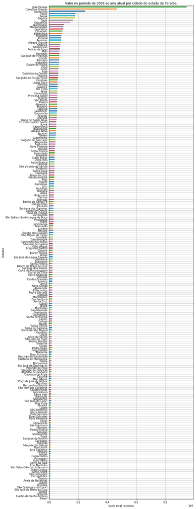

```python
valor_por_cidade_PB.plot.barh(figsize=(10,35)).grid()
plt.title('Valor no período de 2008 ao ano atual por cidade do estado da Paraíba.')
plt.xlabel('Valor total recebido')
plt.ylabel('Cidades')
```

```python
valores_porcentagem_cidade_PB = (valor_por_cidade_PB * 100)/ valor_por_cidade_PB.sum()
```

```
Text(0,0.5,'Cidades')
```

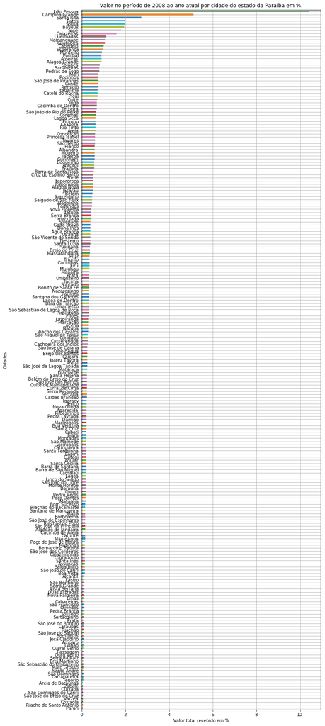

```python
valores_porcentagem.plot.barh(figsize=(10,30)).grid()
plt.title('Valor no período de 2008 ao ano atual por cidade do estado da Paraíba em %.')
plt.xlabel('Valor total recebido em %')
plt.ylabel('Cidades')
```